# Multivariate Encoding of fMRI data

Programming: The Next Step

Lukas Snoek, spring 2015

This notebook describes a multivariate encoding analysis on fMRI data, as described in [Walther et al](http://www.icn.ucl.ac.uk/motorcontrol/pubs/representational_analysis.pdf) This multivariate encoding analysis is argued to be more sensitive than traditional mass-univariate (voxel-wise) fMRI analyses and, in particular, offers an innovative way to analyse and interpret factorial designs.

### Importing necessary packages

We need to import some packages before running any code. This is done similarly to R's library(). We definitely need numpy, Python's numeric computing package, and Matplotlib, Python's main plotting library. Also, I need some previously written code to import a class ("mvpa_mat"), which has a nice format to work with.

We also need to set our path and working directory.

```python
import os
import cPickle
import numpy as np
import glob
import matplotlib.pyplot as plt
import sys
sys.path.append('/home/lukas/Dropbox/ResMas_UvA/Thesis/Git/Analysis_scripts/modules/')

from glm2mvpa import mvpa_mat
import MultivariateEncoding as ME

%pylab inline
```

```
WARNING: pylab import has clobbered these variables: ['test']
`%matplotlib` prevents importing * from pylab and numpy
```

### Simulating data: One subject

Because I don't have appropriate data for this analysis at hand, I'll create a random (gaussian noise) dataset. I need to set some (non-sense) parameters to initialize the useful mvpa_mat object. Here, I assume that our data consists of 60 trials with two factors:

factor_let, with levels 'A' and 'B'

factor_num, with levels '1' and '2'

```python
data = np.random.normal(10, 5, (60, 100))
subject_name = 'test'
mask_name = 'random_gauss'
mask_index = None
mask_shape = None
factor_let = ['a'] * 30 + ['b'] * 30
factor_num = [1] * 15 + [2] * 15 + [1] * 15 + [2] * 15
class_labels = zip(factor_let, factor_num)
```

```python
test = mvpa_mat(data, subject_name, mask_name, mask_index, mask_shape, class_labels)
```

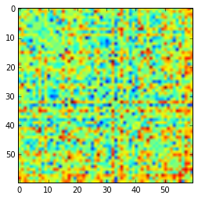

```python
RDM = ME.create_RDM(test)
plt.imshow(RDM)
```

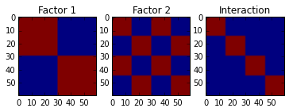

```python
ME.create_rdm_regressor(test)
```